# Lecture 8: Factors, Dates and Times

Joong-Ho Won @ SNU

November 05, 2018

# Factors

In R, factors are used to work with **categorical variables**, variables that have a fixed and known set of possible values.

## Package forcats

- Provides tools for dealing with categorical variables
- *Not* included in the tidyverse.

  ```r
  library(forcats)
  ```

## Creating factors

Suppose you have a variable that records month:

```r
x1 <- c("Dec", "Apr", "Jan", "Mar")
```

Two problems:

1. There are only twelve possible months, and there’s nothing saving you from typos:

   ```r
   x2 <- c("Dec", "Apr", "Jam", "Mar")
   ```

2. It doesn’t sort in a useful way:

   ```r
   sort(x1)
   ```

   ```
   ## [1] "Apr" "Dec" "Jan" "Mar"
   ```

To fix these, use factors:

```r
month_levels <- c(
  "Jan", "Feb", "Mar", "Apr", "May", "Jun",
  "Jul", "Aug", "Sep", "Oct", "Nov", "Dec"
)
y1 <- factor(x1, levels = month_levels)
y1
```

```
## [1] Dec Apr Jan Mar
## Levels: Jan Feb Mar Apr May Jun Jul Aug Sep Oct Nov Dec
```

```r
sort(y1)
```

```
## [1] Jan Mar Apr Dec
## Levels: Jan Feb Mar Apr May Jun Jul Aug Sep Oct Nov Dec
```

Any values not in the set will be silently converted to NA:

```r
y2 <- factor(x2, levels = month_levels)
y2
```

```
## [1] Dec  Apr  <NA> Mar
## Levels: Jan Feb Mar Apr May Jun Jul Aug Sep Oct Nov Dec
```

Omitting levels:

```r
factor(x1)
```

```
## [1] Dec Apr Jan Mar
## Levels: Apr Dec Jan Mar
```

Retrieve the set of valid levels directly:

```r
levels(y1)
```

```
##  [1] "Jan" "Feb" "Mar" "Apr" "May" "Jun" "Jul" "Aug" "Sep" "Oct" "Nov"
## [12] "Dec"
```

## [General Social Survey](http://gss.norc.org)

Long-running US survey conducted by the independent research organization NORC at the University of Chicago.

```r
forcats::gss_cat
```

```
## # A tibble: 21,483 x 9
##     year marital     age race  rincome   partyid   relig   denom   tvhours
##    <int> <fct>     <int> <fct> <fct>     <fct>     <fct>   <fct>     <int>
##  1  2000 Never ma…    26 White $8000 to… Ind,near… Protes… Southe…      12
##  2  2000 Divorced     48 White $8000 to… Not str … Protes… Baptis…      NA
##  3  2000 Widowed      67 White Not appl… Independ… Protes… No den…       2
##  4  2000 Never ma…    39 White Not appl… Ind,near… Orthod… Not ap…       4
##  5  2000 Divorced     25 White Not appl… Not str … None    Not ap…       1
##  6  2000 Married      25 White $20000 -… Strong d… Protes… Southe…      NA
##  7  2000 Never ma…    36 White $25000 o… Not str … Christ… Not ap…       3
##  8  2000 Divorced     44 White $7000 to… Ind,near… Protes… Luther…      NA
##  9  2000 Married      44 White $25000 o… Not str … Protes… Other         0
## 10  2000 Married      47 White $25000 o… Strong r… Protes… Southe…       3
## # ... with 21,473 more rows
```

How many levels?

```r
gss_cat %>%
  count(race)
```

```
## # A tibble: 3 x 2
##   race      n
##   <fct> <int>
## 1 Other  1959
## 2 Black  3129
## 3 White 16395
```

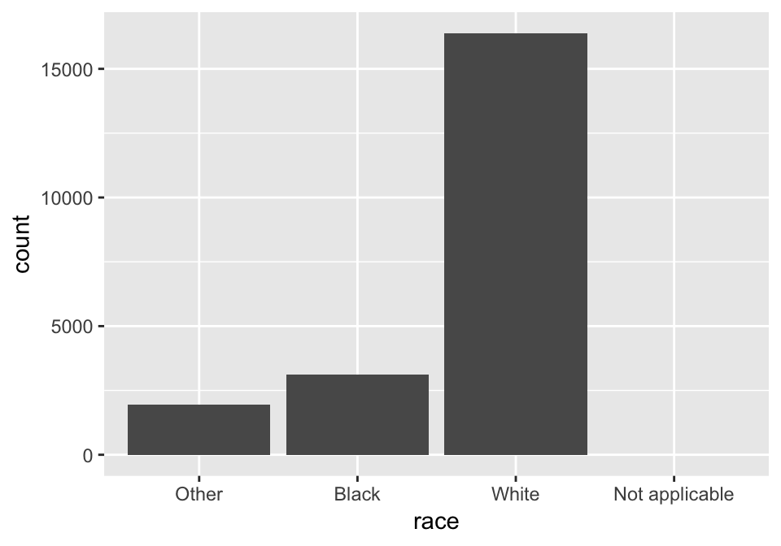

```r
ggplot(gss_cat, aes(race)) +
  geom_bar() +
  scale_x_discrete(drop = FALSE)
```

### Two most common operations with factors

1. Changing the order of the levels
2. Changing the values of the levels

## Modifying factor order

Average number of hours spent watching TV per day across religions:

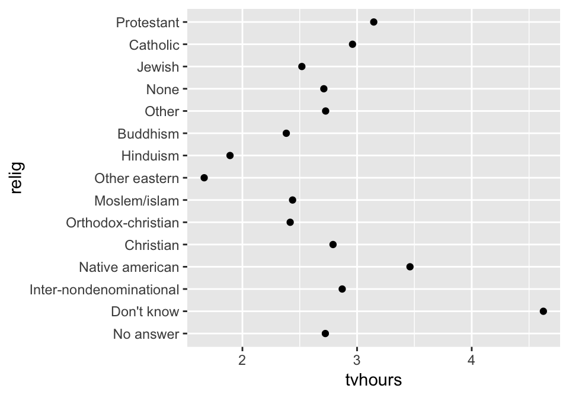

```r
relig_summary <- gss_cat %>%
  group_by(relig) %>%
  summarise(
    age = mean(age, na.rm = TRUE),
    tvhours = mean(tvhours, na.rm = TRUE),
    n = n()
  )

ggplot(relig_summary, aes(tvhours, relig)) + geom_point()
```

vs

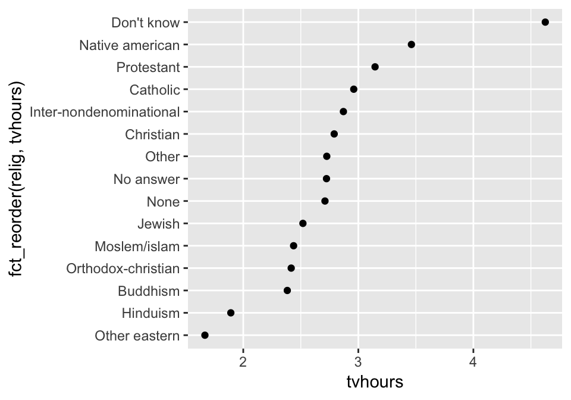

```r
ggplot(relig_summary, aes(tvhours, fct_reorder(relig, tvhours))) +
  geom_point()
```

`fct_reorder(f,x,fun)`: 1. `f`, the factor whose levels you want to modify. 2. `x`, a numeric vector that you want to use to reorder the levels. 3. `fun` (optional), a function used if there are multiple values of `x` for each value of `f`.

Reordering religion makes it much easier to see that people in the “Don’t know” category watch much more TV, and Hinduism & Other Eastern religions watch much less.

Rewrite using `mutate()`:

```r
relig_summary %>%
  mutate(relig = fct_reorder(relig, tvhours)) %>%
  ggplot(aes(tvhours, relig)) +
    geom_point()
```

Reordering isn’t always useful:

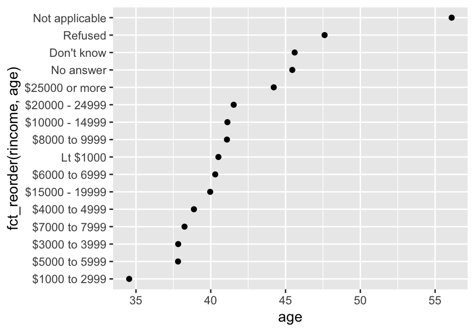

```r
rincome_summary <- gss_cat %>%
  group_by(rincome) %>%
  summarise(
    age = mean(age, na.rm = TRUE),
    tvhours = mean(tvhours, na.rm = TRUE),
    n = n()
  )

ggplot(rincome_summary, aes(age, fct_reorder(rincome, age))) + geom_point()
```

Pull “Not applicable” up front:

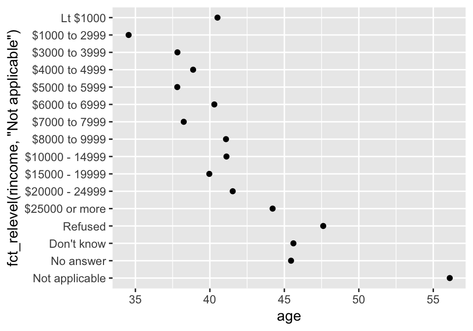

```r
ggplot(rincome_summary, aes(age, fct_relevel(rincome, "Not applicable"))) +
  geom_point()
```

Why do you think the average age for “Not applicable” is so high?

Other useful reordering functions: `fct_reorder()`, `fct_reorder2()`, `fct_infreq()`, `fct_rev()`.

## Modifying factor levels

```r
gss_cat %>% count(partyid)
```

```
## # A tibble: 10 x 2
##    partyid                n
##    <fct>              <int>
##  1 No answer            154
##  2 Don't know             1
##  3 Other party          393
##  4 Strong republican   2314
##  5 Not str republican  3032
##  6 Ind,near rep        1791
##  7 Independent         4119
##  8 Ind,near dem        2499
##  9 Not str democrat    3690
## 10 Strong democrat     3490
```

The levels are terse and inconsistent. Let’s tweak them to be longer and use a parallel construction.

```r
gss_cat %>%
  mutate(partyid = fct_recode(partyid,
    "Republican, strong"    = "Strong republican",
    "Republican, weak"      = "Not str republican",
    "Independent, near rep" = "Ind,near rep",
    "Independent, near dem" = "Ind,near dem",
    "Democrat, weak"        = "Not str democrat",
    "Democrat, strong"      = "Strong democrat"
  )) %>%
  count(partyid)
```

```
## # A tibble: 10 x 2
##    partyid                   n
##    <fct>                 <int>
##  1 No answer               154
##  2 Don't know                1
##  3 Other party             393
##  4 Republican, strong     2314
##  5 Republican, weak       3032
##  6 Independent, near rep  1791
##  7 Independent            4119
##  8 Independent, near dem  2499
##  9 Democrat, weak         3690
## 10 Democrat, strong       3490
```

Combine groups:

```r
gss_cat %>%
  mutate(partyid = fct_recode(partyid,
    "Republican, strong"    = "Strong republican",
    "Republican, weak"      = "Not str republican",
    "Independent, near rep" = "Ind,near rep",
    "Independent, near dem" = "Ind,near dem",
    "Democrat, weak"        = "Not str democrat",
    "Democrat, strong"      = "Strong democrat",
    "Other"                 = "No answer",
    "Other"                 = "Don't know",
    "Other"                 = "Other party"
  )) %>%
  count(partyid)
```

```
## # A tibble: 8 x 2
##   partyid                   n
##   <fct>                 <int>
## 1 Other                   548
## 2 Republican, strong     2314
## 3 Republican, weak       3032
## 4 Independent, near rep  1791
## 5 Independent            4119
## 6 Independent, near dem  2499
## 7 Democrat, weak         3690
## 8 Democrat, strong       3490
```

Collapse a lot of levels:

```r
gss_cat %>%
  mutate(partyid = fct_collapse(partyid,
    other = c("No answer", "Don't know", "Other party"),
    rep = c("Strong republican", "Not str republican"),
    ind = c("Ind,near rep", "Independent", "Ind,near dem"),
    dem = c("Not str democrat", "Strong democrat")
  )) %>%
  count(partyid)
```

```
## # A tibble: 4 x 2
##   partyid     n
##   <fct>   <int>
## 1 other     548
## 2 rep      5346
## 3 ind      8409
## 4 dem      7180
```

Lump small groups together to make a plot or table simpler:

```r
gss_cat %>%
  mutate(relig = fct_lump(relig, n = 10)) %>%
  count(relig, sort = TRUE) %>%
  print(n = Inf)
```

```
## # A tibble: 10 x 2
##    relig                       n
##    <fct>                   <int>
##  1 Protestant              10846
##  2 Catholic                 5124
##  3 None                     3523
##  4 Christian                 689
##  5 Other                     458
##  6 Jewish                    388
##  7 Buddhism                  147
##  8 Inter-nondenominational   109
##  9 Moslem/islam              104
## 10 Orthodox-christian         95
```

# Dates and times

Date and times are much more complicated than they seem:

- Does every year have 365 days?
- Does every day have 24 hours?
- Does every minute have 60 seconds?

Also geopolitics:

- months, time zones, and DST

## Package lubridate

- Makes it easier to work with dates and times in R.
- *Not* included in the tidyverse.

```r
library(lubridate)
library(hms)
```

## Creating date/times

3 data types:

- **Date** (`<date>`)
- **Time** within a day (`<time>`)
- **Date-time** is a date plus a time (`<dttm>`): uniquely identifies an instant in time (typically to the nearest second).

```r
today()  # current date
```

```
## [1] "2018-11-05"
```

```r
now()    # current date-time
```

```
## [1] "2018-11-05 06:07:37 KST"
```

### Date/time from strings

1. `readr::parse_date()` from Lecture 5
2. lubridate:

   ```r
   ymd("2017-01-31")
   ```

   ```
   ## [1] "2017-01-31"
   ```

   ```r
   mdy("January 31st, 2017")
   ```

   ```
   ## [1] "2017-01-31"
   ```

   ```r
   dmy("31-Jan-2017")
   ```

   ```
   ## [1] "2017-01-31"
   ```

   ```r
   ymd(20170131)
   ```

   ```
   ## [1] "2017-01-31"
   ```

   ```r
   ymd_hms("2017-01-31 20:11:59")
   ```

   ```
   ## [1] "2017-01-31 20:11:59 UTC"
   ```

   ```r
   mdy_hm("01/31/2017 08:01")
   ```

   ```
   ## [1] "2017-01-31 08:01:00 UTC"
   ```

### From individual components

Instead of a single string, sometimes you’ll have the individual components of the date-time spread across multiple columns. This is what we have in the flights data:

```r
library(nycflights13)
flights %>%
  select(year, month, day, hour, minute) %>%
  mutate(departure = make_datetime(year, month, day, hour, minute))
```

```
## # A tibble: 336,776 x 6
##     year month   day  hour minute departure
##    <int> <int> <int> <dbl>  <dbl> <dttm>
##  1  2013     1     1     5     15 2013-01-01 05:15:00
##  2  2013     1     1     5     29 2013-01-01 05:29:00
##  3  2013     1     1     5     40 2013-01-01 05:40:00
##  4  2013     1     1     5     45 2013-01-01 05:45:00
##  5  2013     1     1     6      0 2013-01-01 06:00:00
##  6  2013     1     1     5     58 2013-01-01 05:58:00
##  7  2013     1     1     6      0 2013-01-01 06:00:00
##  8  2013     1     1     6      0 2013-01-01 06:00:00
##  9  2013     1     1     6      0 2013-01-01 06:00:00
## 10  2013     1     1     6      0 2013-01-01 06:00:00
## # ... with 336,766 more rows
```

Convert other times:

```r
make_datetime_100 <- function(year, month, day, time) {
  make_datetime(year, month, day, time %/% 100, time %% 100)
}

flights_dt <- flights %>%
  filter(!is.na(dep_time), !is.na(arr_time)) %>%
  mutate(
    dep_time = make_datetime_100(year, month, day, dep_time),
    arr_time = make_datetime_100(year, month, day, arr_time),
    sched_dep_time = make_datetime_100(year, month, day, sched_dep_time),
    sched_arr_time = make_datetime_100(year, month, day, sched_arr_time)
  ) %>%
  select(origin, dest, ends_with("delay"), ends_with("time"))

flights_dt
```

```
## # A tibble: 328,063 x 9
##    origin dest  dep_delay arr_delay dep_time            sched_dep_time
##    <chr>  <chr>     <dbl>     <dbl> <dttm>              <dttm>
##  1 EWR    IAH           2        11 2013-01-01 05:17:00 2013-01-01 05:15:00
##  2 LGA    IAH           4        20 2013-01-01 05:33:00 2013-01-01 05:29:00
##  3 JFK    MIA           2        33 2013-01-01 05:42:00 2013-01-01 05:40:00
##  4 JFK    BQN          -1       -18 2013-01-01 05:44:00 2013-01-01 05:45:00
##  5 LGA    ATL          -6       -25 2013-01-01 05:54:00 2013-01-01 06:00:00
##  6 EWR    ORD          -4        12 2013-01-01 05:54:00 2013-01-01 05:58:00
##  7 EWR    FLL          -5        19 2013-01-01 05:55:00 2013-01-01 06:00:00
##  8 LGA    IAD          -3       -14 2013-01-01 05:57:00 2013-01-01 06:00:00
##  9 JFK    MCO          -3        -8 2013-01-01 05:57:00 2013-01-01 06:00:00
## 10 LGA    ORD          -2         8 2013-01-01 05:58:00 2013-01-01 06:00:00
## # ... with 328,053 more rows, and 3 more variables: arr_time <dttm>,
## #   sched_arr_time <dttm>, air_time <dbl>
```

Distribution of departure times across the year:

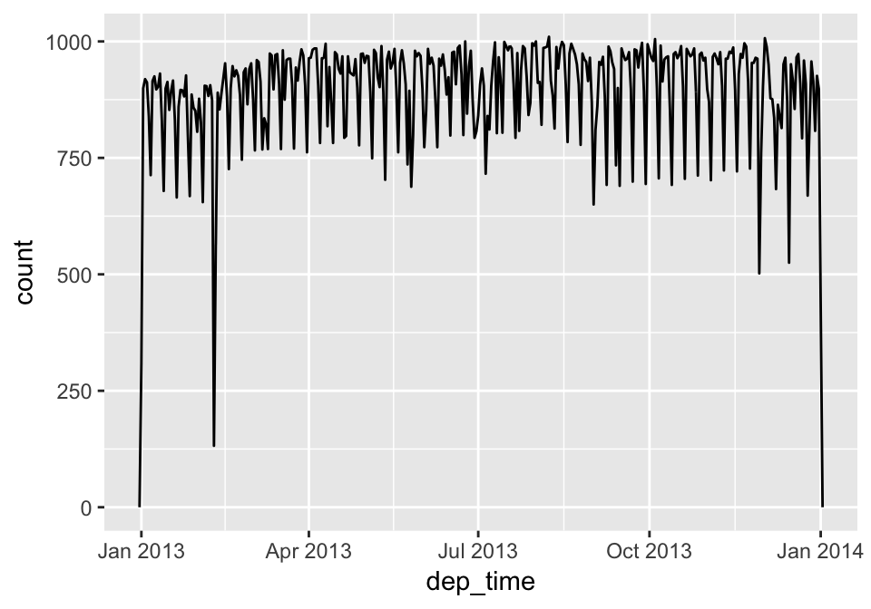

```r
flights_dt %>%
  ggplot(aes(dep_time)) +
  geom_freqpoly(binwidth = 86400) # 86400 seconds = 1 day
```

Or within a single day:

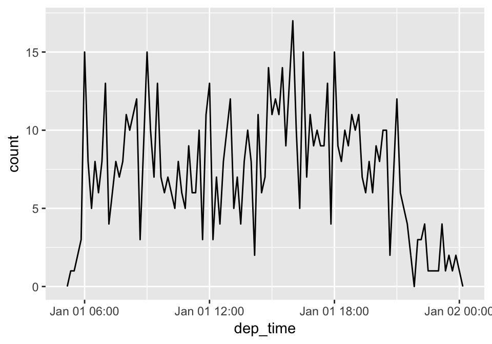

```r
flights_dt %>%
  filter(dep_time < ymd(20130102)) %>%
  ggplot(aes(dep_time)) +
  geom_freqpoly(binwidth = 600) # 600 s = 10 minutes
```

### From other types

Switch between a date-time and a date:

```r
as_datetime(today())
```

```
## [1] "2018-11-05 UTC"
```

```r
as_date(now())
```

```
## [1] "2018-11-05"
```

## Date-time components

Now that you know how to get date-time data into R’s date-time data structures, let’s explore what you can do with them. This section will focus on the accessor functions that let you get and set individual components. The next section will look at how arithmetic works with date-times.

### Getting components

Accessor functions: `year()`, `month()`, `mday()` (day of the month), `yday()` (day of the year), `wday()` (day of the week), `hour()`, `minute()`, and `second()`.

Do more flights depart during the week than on the weekend?

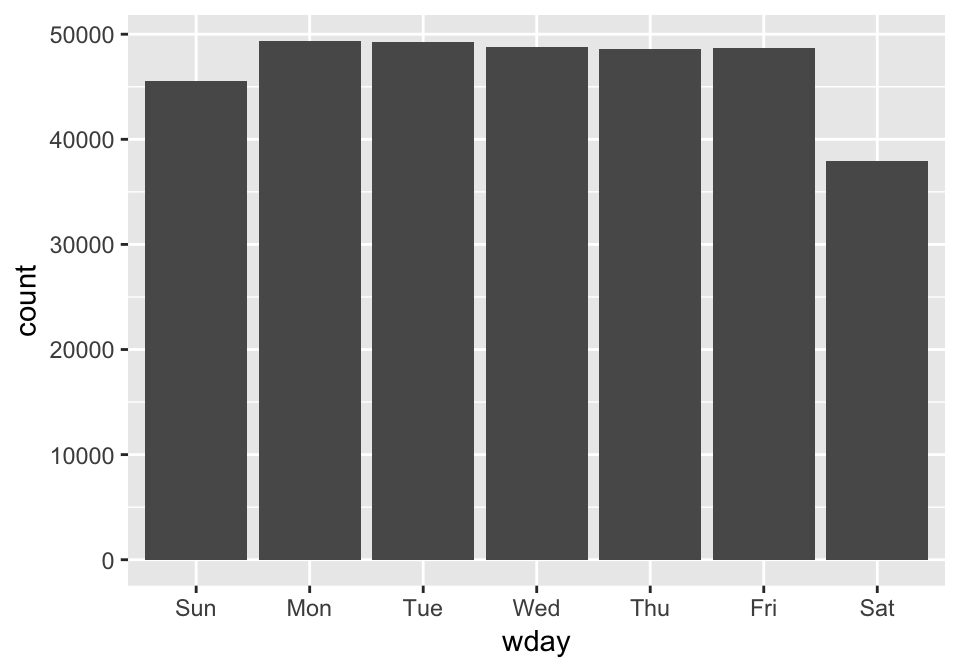

```r
flights_dt %>%
  mutate(wday = wday(dep_time, label = TRUE)) %>%
  ggplot(aes(x = wday)) +
    geom_bar()
```

Average departure delay by minute within the hour in actual departure time:

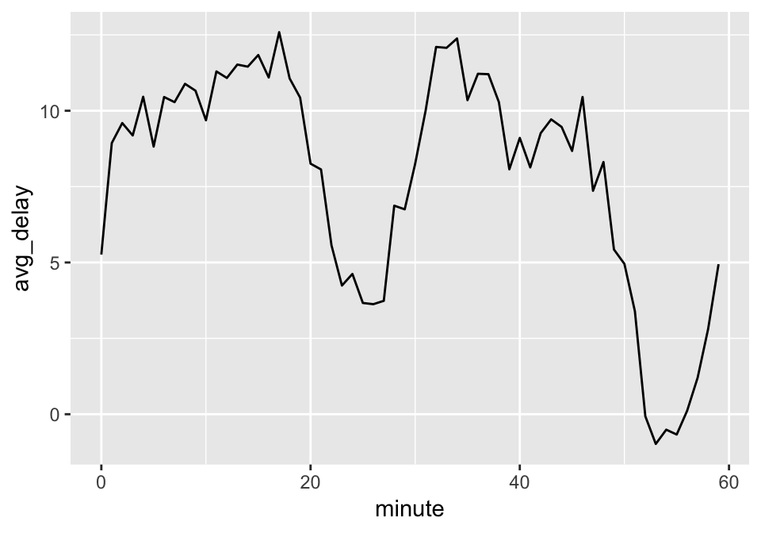

```r
flights_dt %>%
  mutate(minute = minute(dep_time)) %>%
  group_by(minute) %>%
  summarise(
    avg_delay = mean(arr_delay, na.rm = TRUE),
    n = n()) %>%
  ggplot(aes(minute, avg_delay)) +
    geom_line()
```

It looks like flights leaving in minutes 20-30 and 50-60 have much lower delays than the rest of the hour!

Average departure delay by minute within the hour in *scheduled* departure time:

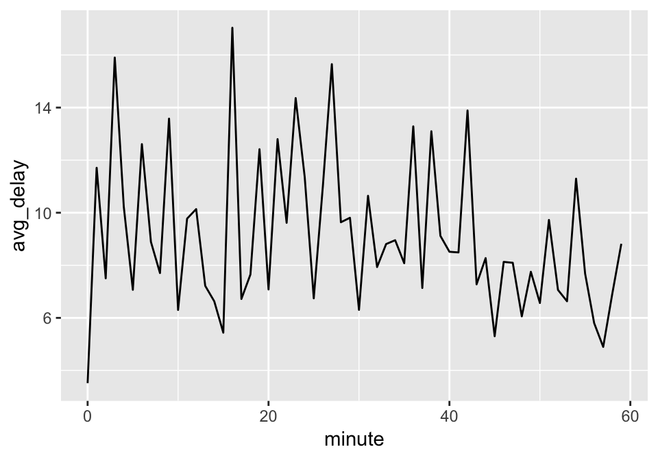

```r
sched_dep <- flights_dt %>%
  mutate(minute = minute(sched_dep_time)) %>%
  group_by(minute) %>%
  summarise(
    avg_delay = mean(arr_delay, na.rm = TRUE),
    n = n())

ggplot(sched_dep, aes(minute, avg_delay)) +
  geom_line()
```

We don’t see such a strong pattern.

So why do we see that pattern with the actual departure times?

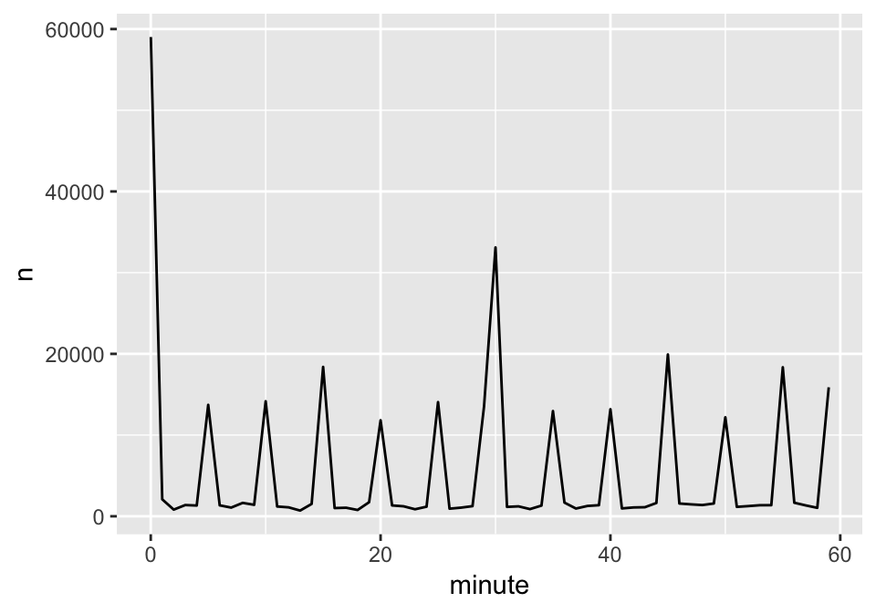

```r
ggplot(sched_dep, aes(minute, n)) +
  geom_line()
```

### Rounding

Number of flights per week:

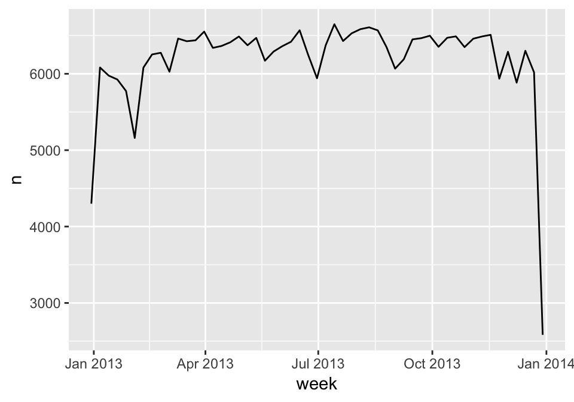

```r
flights_dt %>%
  count(week = floor_date(dep_time, "week")) %>%
  ggplot(aes(week, n)) +
    geom_line()
```

Computing the difference between a rounded and unrounded date can be particularly useful.

### Setting components

Accessor functions: `year()`, `month()`, `mday()` (day of the month), `yday()` (day of the year), `wday()` (day of the week), `hour()`, `minute()`, and `second()`.

```r
(datetime <- ymd_hms("2016-07-08 12:34:56"))
```

```
## [1] "2016-07-08 12:34:56 UTC"
```

```r
year(datetime) <- 2020
datetime
```

```
## [1] "2020-07-08 12:34:56 UTC"
```

Alternatively, use `update()`:

```r
update(datetime, year = 2020, month = 2, mday = 2, hour = 2)
```

```
## [1] "2020-02-02 02:34:56 UTC"
```

Distribution of flights across the course of the day for every day of the year:

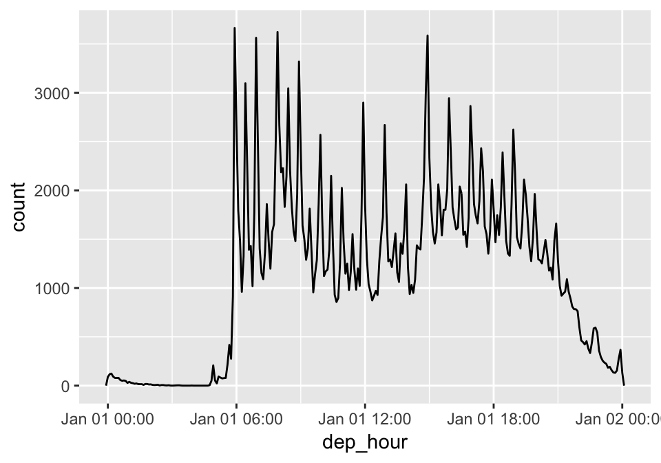

```r
flights_dt %>%
  mutate(dep_hour = update(dep_time, yday = 1)) %>%
  ggplot(aes(dep_hour)) +
    geom_freqpoly(binwidth = 300)
```

## Time arithmetic

```r
# How old is Hadley?
h_age <- today() - ymd(19791014)
h_age
```

```
## Time difference of 14267 days
```

### Durations

```r
as.duration(h_age)
```

```
## [1] "1232668800s (~39.06 years)"
```

Constructing durations: `dseconds()`, `dminutes()`, `dhours()`, etc.

Arithmetic:

```r
2 * dyears(1)
```

```
## [1] "63072000s (~2 years)"
```

```r
dyears(1) + dweeks(12) + dhours(15)
```

```
## [1] "38847600s (~1.23 years)"
```

```r
tomorrow <- today() + ddays(1)
last_year <- today() - dyears(1)
```

Sometimes a day is not 24 hours:

```r
one_pm <- ymd_hms("2016-03-12 13:00:00", tz = "America/New_York")

one_pm
```

```
## [1] "2016-03-12 13:00:00 EST"
```

```r
one_pm + ddays(1)
```

```
## [1] "2016-03-13 14:00:00 EDT"
```

### Periods

To resolve this problem, use **periods**:

```r
one_pm
```

```
## [1] "2016-03-12 13:00:00 EST"
```

```r
one_pm + days(1)
```

```
## [1] "2016-03-13 13:00:00 EDT"
```

Time travel?

```r
flights_dt %>%
  filter(arr_time < dep_time) %>%
    select(origin, dest, dep_time, arr_time)
```

```
## # A tibble: 10,633 x 4
##    origin dest  dep_time            arr_time
##    <chr>  <chr> <dttm>              <dttm>
##  1 EWR    BQN   2013-01-01 19:29:00 2013-01-01 00:03:00
##  2 JFK    DFW   2013-01-01 19:39:00 2013-01-01 00:29:00
##  3 EWR    TPA   2013-01-01 20:58:00 2013-01-01 00:08:00
##  4 EWR    SJU   2013-01-01 21:02:00 2013-01-01 01:46:00
##  5 EWR    SFO   2013-01-01 21:08:00 2013-01-01 00:25:00
##  6 LGA    FLL   2013-01-01 21:20:00 2013-01-01 00:16:00
##  7 EWR    MCO   2013-01-01 21:21:00 2013-01-01 00:06:00
##  8 JFK    LAX   2013-01-01 21:28:00 2013-01-01 00:26:00
##  9 EWR    FLL   2013-01-01 21:34:00 2013-01-01 00:20:00
## 10 EWR    FLL   2013-01-01 21:36:00 2013-01-01 00:25:00
## # ... with 10,623 more rows
```

These are overnight flights.

```r
flights_dt <- flights_dt %>%
  mutate(
    overnight = arr_time < dep_time,
    arr_time = arr_time + days(overnight * 1),  # why * 1?
    sched_arr_time = sched_arr_time + days(overnight * 1)
  )
```

Now all of our flights obey the laws of physics.

```r
flights_dt %>%
  filter(overnight, arr_time < dep_time)
```

```
## # A tibble: 0 x 10
## # ... with 10 variables: origin <chr>, dest <chr>, dep_delay <dbl>,
## #   arr_delay <dbl>, dep_time <dttm>, sched_dep_time <dttm>,
## #   arr_time <dttm>, sched_arr_time <dttm>, air_time <dbl>,
## #   overnight <lgl>
```

### Intervals

```r
dyears(1) / ddays(365) # this is precisely defined
```

```
## [1] 1
```

```r
years(1) / days(1)
```

```
## estimate only: convert to intervals for accuracy
```

```
## [1] 365.25
```

An **interval** is a duration with a starting point:

```r
next_year <- today() + years(1)
(today() %--% next_year) / ddays(1)
```

```
## [1] 365
```

## [Time zones](http://www.iana.org/time-zones)

Your current time zone is with `Sys.timezone()`:

```r
Sys.timezone()
```

```
## [1] "Asia/Seoul"
```

In R, the time zone is an attribute of the date-time that only controls printing.

```r
(x1 <- ymd_hms("2015-06-01 12:00:00", tz = "America/New_York"))
```

```
## [1] "2015-06-01 12:00:00 EDT"
```

```r
(x2 <- ymd_hms("2015-06-01 18:00:00", tz = "Europe/Copenhagen"))
```

```
## [1] "2015-06-01 18:00:00 CEST"
```

```r
(x3 <- ymd_hms("2015-06-02 04:00:00", tz = "Pacific/Auckland"))
```

```
## [1] "2015-06-02 04:00:00 NZST"
```

They are the same:

```r
x1 - x2
```

```
## Time difference of 0 secs
```

```r
x1 - x3
```

```
## Time difference of 0 secs
```

### UTC

Unless otherwise specified, lubridate always uses UTC (Coordinated Universal Time), the standard time zone used by the scientific community:

```r
(x4 <- ymd_hms(now()))
```

```
## [1] "2018-11-05 06:07:48 UTC"
```

### Changing the time zone

1. Keep the instant in time the same, and change how it’s displayed.

   ```r
   x4a <- with_tz(x4, tzone = "Asia/Shanghai")
   x4a
   ```

   ```
   ## [1] "2018-11-05 14:07:48 CST"
   ```

   ```r
   x4a - x4
   ```

   ```
   ## Time difference of 0 secs
   ```

2. Change the underlying instant in time (when you have an instant that has been labelled with the incorrect time zone, and you need to fix it).

   ```r
   x4b <- force_tz(x4, tzone = "Asia/Shanghai")
   x4b
   ```

   ```
   ## [1] "2018-11-05 06:07:48 CST"
   ```

   ```r
   x4b - x4
   ```

   ```
   ## Time difference of -8 hours
   ```